# Unsupervised Learning: Trade&Ahead

## K-means Clustering

- We will try 1-9 number for k.

```python
# to compute distances
from scipy.spatial.distance import cdist
```

```
Number of Clusters: 1 	Average Distortion: 2.5425069919221697
Number of Clusters: 2 	Average Distortion: 2.382318498894466
Number of Clusters: 3 	Average Distortion: 2.2692367155390745
Number of Clusters: 4 	Average Distortion: 2.1745559827866363
Number of Clusters: 5 	Average Distortion: 2.128799332840716
Number of Clusters: 6 	Average Distortion: 2.080400099226289
Number of Clusters: 7 	Average Distortion: 2.0289794220177395
Number of Clusters: 8 	Average Distortion: 1.964144163389972
Number of Clusters: 9 	Average Distortion: 1.9221492045198068
```

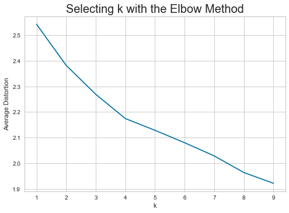

```python
clusters = range(1, 10)
meanDistortions = []

for k in clusters:
    model = KMeans(n_clusters=k, random_state=1)
    model.fit(subset_scaled_df1)
    prediction = model.predict(subset_scaled_df1)
    distortion = (
        sum(
            np.min(
                cdist(subset_scaled_df1, model.cluster_centers_, "euclidean"), axis=1
            )
        )
        / subset_scaled_df1.shape[0]
    )

    meanDistortions.append(distortion)

    print("Number of Clusters:", k, "\tAverage Distortion:", distortion)

plt.plot(clusters, meanDistortions, "bx-")
plt.xlabel("k")
plt.ylabel("Average Distortion")
plt.title("Selecting k with the Elbow Method", fontsize=20)
```

**The appropriate value of k from the elbow curve seems to be 4.**

```
For n_clusters = 2, silhouette score is 0.43969639509980457
For n_clusters = 3, silhouette score is 0.45494915445064904
For n_clusters = 4, silhouette score is 0.4495910932182279
For n_clusters = 5, silhouette score is 0.45199200718666577
For n_clusters = 6, silhouette score is 0.3820408735510609
For n_clusters = 7, silhouette score is 0.37302514984424046
For n_clusters = 8, silhouette score is 0.4143420508969727
For n_clusters = 9, silhouette score is 0.2254557094998536
```

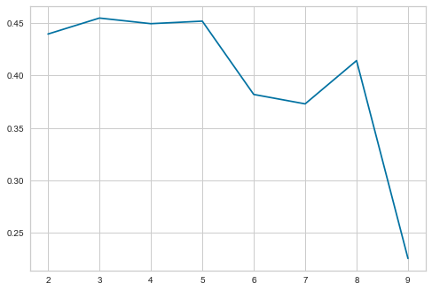

```python
sil_score = []
cluster_list = list(range(2, 10))
for n_clusters in cluster_list:
    clusterer = KMeans(n_clusters=n_clusters)
    preds = clusterer.fit_predict((subset_scaled_df1))
    # centers = clusterer.cluster_centers_
    score = silhouette_score(subset_scaled_df1, preds)
    sil_score.append(score)
    print("For n_clusters = {}, silhouette score is {}".format(n_clusters, score))

plt.plot(cluster_list, sil_score)
```

**From the silhouette scores, it seems that 3 or 5 are good values of k.**

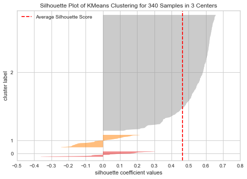

```python
# finding optimal no. of clusters with silhouette coefficients
visualizer = SilhouetteVisualizer(KMeans(3, random_state=1))
visualizer.fit(subset_scaled_df1)
visualizer.show()
```

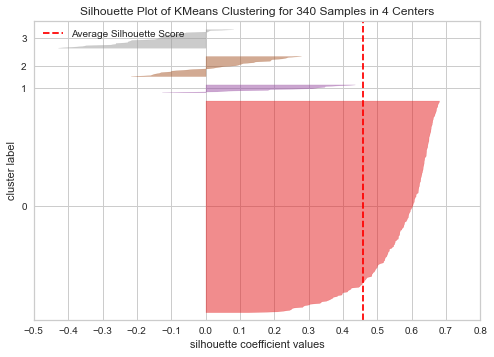

```python
# finding optimal no. of clusters with silhouette coefficients
visualizer = SilhouetteVisualizer(KMeans(4, random_state=1))
visualizer.fit(subset_scaled_df1)
visualizer.show()
```

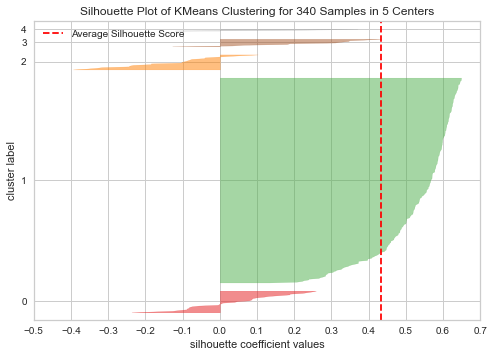

```python
# finding optimal no. of clusters with silhouette coefficients
visualizer = SilhouetteVisualizer(KMeans(5, random_state=1))
visualizer.fit(subset_scaled_df1)
visualizer.show()
```

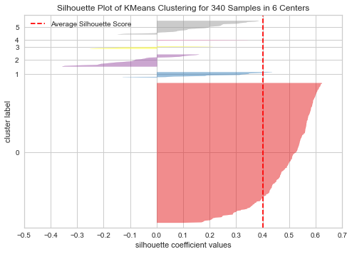

```python
# finding optimal no. of clusters with silhouette coefficients
visualizer = SilhouetteVisualizer(KMeans(6, random_state=1))
visualizer.fit(subset_scaled_df1)
visualizer.show()
```

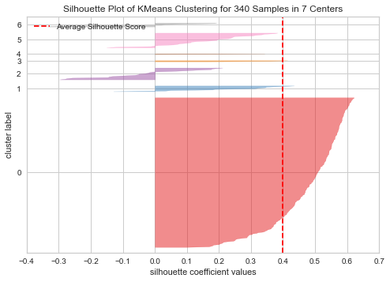

```python
# finding optimal no. of clusters with silhouette coefficients
visualizer = SilhouetteVisualizer(KMeans(7, random_state=1))
visualizer.fit(subset_scaled_df1)
visualizer.show()
```

**Let's take 5 as the appropriate no. of clusters as the silhouette score is highest enough and 5 is in between the 2 elbow curves at 4 and 8.**

### K=5

```python
kmeans = KMeans(n_clusters=5, random_state=0)
kmeans.fit(subset_scaled_df1)
```

```
KMeans(n_clusters=5, random_state=0)
```

```python
# adding kmeans cluster labels to the original dataframe
df1["K_means_segments"] = kmeans.labels_
```

```python
cluster_profile = df1.groupby("K_means_segments").mean()
```

```python
cluster_profile["count_in_each_segment"] = (
    df1.groupby("K_means_segments")["Price_Change"].count().values
)
```

```python
# let's display cluster profiles
cluster_profile.style.highlight_max(color="lightgreen", axis=0)
```

| K_means_segments | Current_Price | Price_Change | Volatility | ROE | Cash_Ratio | Net_Cash_Flow | Net_Income | Earnings_Per_Share | Estimated_Shares_Outstanding | P_E_Ratio | P_B_Ratio | count_in_each_segment |
| --- | --- | --- | --- | --- | --- | --- | --- | --- | --- | --- | --- | --- |
| 0 | 246.574304 | 14.284326 | 1.769621 | 26.500000 | 279.916667 | 459120250.000000 | 1009205541.666667 | 6.167917 | 549432140.538333 | 90.097512 | 14.081386 | 24 |
| 1 | 41.373681 | -14.849938 | 2.596790 | 27.285714 | 64.457143 | 34462657.142857 | -1293864285.714286 | -2.459714 | 450100420.905143 | 61.563930 | 2.476202 | 35 |
| 2 | 48.103077 | 6.053507 | 1.163964 | 27.538462 | 77.230769 | 773230769.230769 | 14114923076.923077 | 3.958462 | 3918734987.169230 | 16.098039 | -4.253404 | 13 |
| 3 | 72.783335 | 0.912232 | 2.015435 | 542.666667 | 34.000000 | -350866666.666667 | -5843677777.777778 | -14.735556 | 372500020.988889 | 53.574485 | -8.831054 | 9 |
| 4 | 72.768128 | 5.701175 | 1.359857 | 25.598456 | 52.216216 | -913081.081081 | 1537660934.362934 | 3.719247 | 436114647.527683 | 23.473934 | -3.374716 | 259 |

- Count on each segment looks good. They seem to have enough variety in each segments.

## Dimensionality Reduction using PCA for visualization

- Let's use PCA to reduce the data to two dimensions and visualize it to see how well-separated the clusters are.

```python
# importing library
from sklearn.decomposition import PCA

# setting the number of components to 2
pca = PCA(n_components=2)

# transforming data and storing results in a dataframe
X_reduced_pca = pca.fit_transform(subset_scaled_df1)
reduced_df_pca = pd.DataFrame(
    data=X_reduced_pca, columns=["Component 1", "Component 2"]
)  # checking the amount of variance explained
pca.explained_variance_ratio_.sum()
```

```
0.37128995677258525
```

```python
# Append the prediction
subset_scaled_df1["GROUP"] = df1["K_means_segments"]
```

```python
# sns.scatterplot(data=reduced_df_pca, x="Component 1", y="Component 2")
```

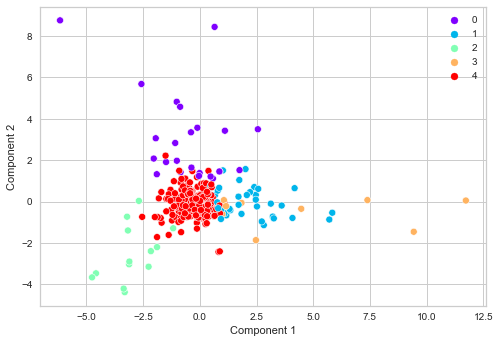

```python
sns.scatterplot(
    data=reduced_df_pca,
    x="Component 1",
    y="Component 2",
    hue=subset_scaled_df1["GROUP"],
    palette="rainbow",
)
plt.legend(bbox_to_anchor=(1, 1))
```

Now the clusters seem to have more variability.

### Observations:

- From the two dimensions graph, we can see that Group 4 is well defined as a cluster.
- Group 0, Group 1, and Group 2 are not quite spreaded out, however, we could see that they are seperated.
- Group 3 is the smallest cluster and they are spead outed, but those points seem to be located in the same area in the graph.
- We are satisfied with 5 as K.

## Cluster Profiling: KMeans

```python
cluster_profile = df1.groupby("K_means_segments").mean()
```

```python
# Let us first start with K = 5
final_model = KMeans(5)
final_model.fit(subset_scaled_df1)
prediction = final_model.predict(subset_scaled_df1)

# Append the prediction
subset_scaled_df1["GROUP"] = prediction
subset_scaled_df1["GROUP"] = prediction
print("Groups Assigned : \n")
subset_scaled_df1.head()
```

```
Groups Assigned :
```

|  | Current_Price | Price_Change | Volatility | ROE | Cash_Ratio | Net_Cash_Flow | Net_Income | Earnings_Per_Share | Estimated_Shares_Outstanding | P_E_Ratio | P_B_Ratio | GROUP |
| --- | --- | --- | --- | --- | --- | --- | --- | --- | --- | --- | --- | --- |
| 0 | -0.393341 | 0.493950 | 0.272749 | 0.989601 | -0.210698 | -0.339355 | 1.554415 | 1.309399 | 0.107863 | -0.652487 | -0.506653 | 1 |
| 1 | -0.220837 | 0.355439 | 1.137045 | 0.937737 | 0.077269 | -0.002335 | 0.927628 | 0.056755 | 1.250274 | -0.311769 | -0.504205 | 1 |
| 2 | -0.367195 | 0.602479 | -0.427007 | -0.192905 | -0.033488 | 0.454058 | 0.744371 | 0.024831 | 1.098021 | -0.391502 | 0.094941 | 1 |
| 3 | 0.133567 | 0.825696 | -0.284802 | -0.317379 | 1.218059 | -0.152497 | -0.219816 | -0.230563 | -0.091622 | 0.947148 | 0.424333 | 1 |
| 4 | -0.260874 | -0.492636 | 0.296470 | -0.265515 | 2.237018 | 0.133564 | -0.202703 | -0.374982 | 1.978399 | 3.293307 | 0.199196 | 4 |

```python
# let's see the names of the name of companies in each cluster
for cl in df1["K_means_segments"].unique():
    print("In cluster {}, the following companies are present:".format(cl))
    print(df1[df1["K_means_segments"] == cl]["Security"].unique())
    print()
```

```
In cluster 4, the following companies are present:
['American Airlines Group' 'AbbVie' 'Abbott Laboratories'
 'Adobe Systems Inc' 'Archer-Daniels-Midland Co' 'Ameren Corp'
 'American Electric Power' 'AFLAC Inc'
 'American International Group, Inc.' 'Apartment Investment & Mgmt'
 'Assurant Inc' 'Arthur J. Gallagher & Co.' 'Albemarle Corp'
 'Alaska Air Group Inc' 'Allstate Corp' 'Applied Materials Inc'
 'AMETEK Inc' 'Affiliated Managers Group Inc' 'Ameriprise Financial'
 'American Tower Corp A' 'AutoNation Inc' 'Anthem Inc.' 'Aon plc'
 'Amphenol Corp' 'Activision Blizzard' 'AvalonBay Communities, Inc.'
 'Broadcom' 'American Water Works Company Inc' 'American Express Co'
 'Boeing Company' 'Baxter International Inc.' 'BB&T Corporation'
 'Bard (C.R.) Inc.' 'The Bank of New York Mellon Corp.' 'Ball Corp'
 'Bristol-Myers Squibb' 'Boston Scientific' 'BorgWarner'
 'Boston Properties' 'Caterpillar Inc.' 'Chubb Limited' 'CBRE Group'
 'Crown Castle International Corp.' 'Carnival Corp.'
 'Citizens Financial Group' 'Church & Dwight' 'C. H. Robinson Worldwide'
 'CIGNA Corp.' 'Cincinnati Financial' 'Comerica Inc.' 'CME Group Inc.'
 'Cummins Inc.' 'CMS Energy' 'Centene Corporation' 'CenterPoint Energy'
 'Capital One Financial' 'The Cooper Companies' 'CSX Corp.'
 'CenturyLink Inc' 'Cognizant Technology Solutions' 'Citrix Systems'
 'CVS Health' 'Chevron Corp.' 'Dominion Resources' 'Delta Air Lines'
 'Du Pont (E.I.)' 'Deere & Co.' 'Discover Financial Services'
 'Quest Diagnostics' 'Danaher Corp.' 'The Walt Disney Company'
 'Discovery Communications-A' 'Discovery Communications-C'
 'Delphi Automotive' 'Digital Realty Trust' 'Dun & Bradstreet'
 'Dover Corp.' 'Dr Pepper Snapple Group' 'Duke Energy' 'DaVita Inc.'
 'eBay Inc.' 'Ecolab Inc.' 'Consolidated Edison' 'Equifax Inc.'
 "Edison Int'l" 'Eastman Chemical' 'Equity Residential'
 'Eversource Energy' 'Essex Property Trust, Inc.' 'E*Trade'
 'Eaton Corporation' 'Entergy Corp.' 'Exelon Corp.' "Expeditors Int'l"
 'Expedia Inc.' 'Extra Space Storage' 'Fastenal Co'
 'Fortune Brands Home & Security' 'FirstEnergy Corp'
 'Fidelity National Information Services' 'Fiserv Inc' 'FLIR Systems'
 'Fluor Corp.' 'Flowserve Corporation' 'FMC Corporation'
 'Federal Realty Investment Trust' 'General Dynamics'
 'General Growth Properties Inc.' 'Corning Inc.' 'General Motors'
 'Genuine Parts' 'Garmin Ltd.' 'Goodyear Tire & Rubber'
 'Grainger (W.W.) Inc.' 'Hasbro Inc.' 'Huntington Bancshares'
 'HCA Holdings' 'Welltower Inc.' 'HCP Inc.' 'Hartford Financial Svc.Gp.'
```

[output cut: 62 more lines]

```
 'Occidental Petroleum' 'Quanta Services Inc.' 'Ryder System'
 'Range Resources Corp.' 'Spectra Energy Corp.' 'Skyworks Solutions'
 'Southwestern Energy' 'Teradata Corp.' 'Under Armour' 'Williams Cos.'
 'Cimarex Energy']

In cluster 3, the following companies are present:
['Allegion' 'Apache Corporation' 'Chesapeake Energy'
 'Charter Communications' 'Colgate-Palmolive' 'Devon Energy Corp.'
 'Kimberly-Clark' 'Newfield Exploration Co' 'S&P Global, Inc.']

In cluster 2, the following companies are present:
['Bank of America Corp' 'Citigroup Inc.' 'Ford Motor' 'Gilead Sciences'
 'Intel Corp.' 'JPMorgan Chase & Co.' 'Coca Cola Company' 'Merck & Co.'
 'Pfizer Inc.' 'AT&T Inc' 'Verizon Communications' 'Wells Fargo'
 'Exxon Mobil Corp.']
```

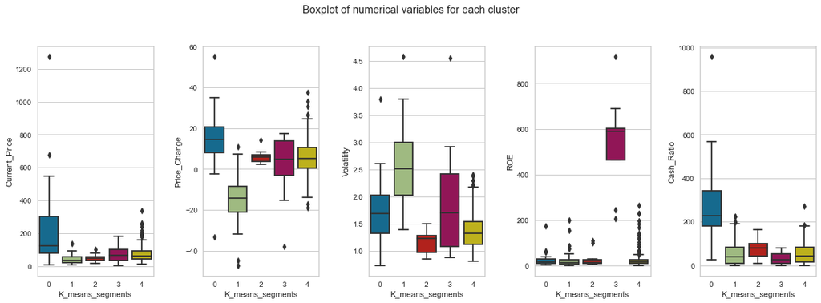

```python
fig, axes = plt.subplots(1, 5, figsize=(16, 6))
fig.suptitle("Boxplot of numerical variables for each cluster")
counter = 0
for ii in range(5):
    sns.boxplot(ax=axes[ii], y=df1[num_cols[counter]], x=df1["K_means_segments"])
    counter = counter + 1

fig.tight_layout(pad=2.0)
```

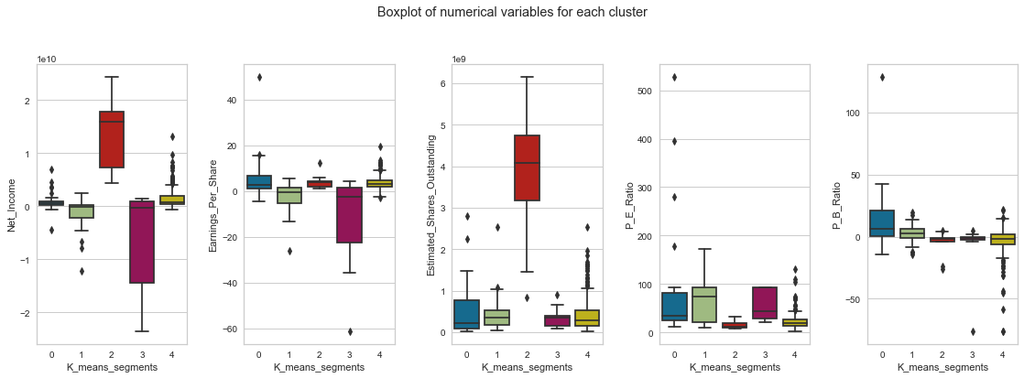

```python
fig, axes = plt.subplots(1, 5, figsize=(16, 6))
fig.suptitle("Boxplot of numerical variables for each cluster")
counter = 6
for ii in range(5):
    sns.boxplot(ax=axes[ii], y=df1[num_cols[counter]], x=df1["K_means_segments"])
    counter = counter + 1

fig.tight_layout(pad=2.0)
```

### Insights

- **Cluster 0**:
  - moderate to very high current price (the highest in all clusters) and moderate positive price change (the highest in all clusters), moderate volatility
  - very high cash ratio, with a positive net cash flow and a positive net income
  - the highest earnings per share with the highest P/E ratio and P/B.
- **Cluster 1**:
  - low to moderate current price and the highest negative price change, the highest volatility
  - moderate cash ratio with positive cash flow but negative net income
  - negative earnings per share, with high P/E ratio and moderate P/B ratio
- **Cluster 2**:
  - moderate current price and a high positive price change, with low volatility
  - moderate to high cash ratio with very high net cash flow and net income (the highest in all clusters)
  - moderate to high earnings per share with the high estimated shares outstanding (the highest in all clusters)
  - low P/E ratio and negative P/B ration
- **Cluster 3**:
  - moderate to high current price and low price change, with moderate to high volatility
  - very high ROE (the highest in all clusters)
  - low cash ratio, with high negative net cash flow and net income
  - high negative earnings per share, with high P/E but negative P/B
- **Cluster 4**:
  - moderate to high current price and high price change, with low volatility
  - moderate cash ratio, with negative cash flow and positive net income
  - moderate earnings per share, with moderate P/E ratio and negative P/B ratio

## Hierarchical Clustering

```python
# cophenet index is a measure of the correlation between the distance of points in feature space and distance on dendrogram
# closer it is to 1, the better is the clustering

Z = linkage(subset_scaled_df1, metric="euclidean", method="average")
c, coph_dists = cophenet(Z, pdist(subset_scaled_df1))

c
```

```
0.9440674244845398
```

```python
# list of distance metrics
distance_metrics = ["euclidean", "chebyshev", "mahalanobis", "cityblock"]

# list of linkage methods
linkage_methods = ["single", "complete", "average", "weighted"]

high_cophenet_corr = 0
high_dm_lm = [0, 0]

for dm in distance_metrics:
    for lm in linkage_methods:
        Z = linkage(subset_scaled_df1, metric=dm, method=lm)
        c, coph_dists = cophenet(Z, pdist(subset_scaled_df1))
        print(
            "Cophenetic correlation for {} distance and {} linkage is {}.".format(
                dm.capitalize(), lm, c
            )
        )
        if high_cophenet_corr < c:
            high_cophenet_corr = c
            high_dm_lm[0] = dm
            high_dm_lm[1] = lm
```

```
Cophenetic correlation for Euclidean distance and single linkage is 0.9268536395121735.
Cophenetic correlation for Euclidean distance and complete linkage is 0.8306256721298431.
Cophenetic correlation for Euclidean distance and average linkage is 0.9440674244845398.
Cophenetic correlation for Euclidean distance and weighted linkage is 0.8899012907677044.
Cophenetic correlation for Chebyshev distance and single linkage is 0.9057709090055758.
Cophenetic correlation for Chebyshev distance and complete linkage is 0.7863567385649622.
Cophenetic correlation for Chebyshev distance and average linkage is 0.934814252205591.
Cophenetic correlation for Chebyshev distance and weighted linkage is 0.9089354946517795.
Cophenetic correlation for Mahalanobis distance and single linkage is 0.9317881846217679.
Cophenetic correlation for Mahalanobis distance and complete linkage is 0.7854964969358097.
Cophenetic correlation for Mahalanobis distance and average linkage is 0.9371075204838313.
Cophenetic correlation for Mahalanobis distance and weighted linkage is 0.8944223174449266.
Cophenetic correlation for Cityblock distance and single linkage is 0.9317097452710296.
Cophenetic correlation for Cityblock distance and complete linkage is 0.7599765128247576.
Cophenetic correlation for Cityblock distance and average linkage is 0.9188599857107359.
Cophenetic correlation for Cityblock distance and weighted linkage is 0.8354993865793068.
```

```python
# printing the combination of distance metric and linkage method with the highest cophenetic correlation
print(
    "Highest cophenetic correlation is {}, which is obtained with {} distance and {} linkage.".format(
        high_cophenet_corr, high_dm_lm[0].capitalize(), high_dm_lm[1]
    )
)
```

```
Highest cophenetic correlation is 0.9440674244845398, which is obtained with Euclidean distance and average linkage.
```

**Let's explore different linkage methods with Euclidean distance only.**

```python
# list of linkage methods
linkage_methods = ["single", "complete", "average", "centroid", "ward", "weighted"]

high_cophenet_corr = 0
high_dm_lm = [0, 0]

for lm in linkage_methods:
    Z = linkage(subset_scaled_df1, metric="euclidean", method=lm)
    c, coph_dists = cophenet(Z, pdist(subset_scaled_df1))
    print("Cophenetic correlation for {} linkage is {}.".format(lm, c))
    if high_cophenet_corr < c:
        high_cophenet_corr = c
        high_dm_lm[0] = "euclidean"
        high_dm_lm[1] = lm
```

```
Cophenetic correlation for single linkage is 0.9268536395121735.
Cophenetic correlation for complete linkage is 0.8306256721298431.
Cophenetic correlation for average linkage is 0.9440674244845398.
Cophenetic correlation for centroid linkage is 0.9462105731282348.
Cophenetic correlation for ward linkage is 0.7062735518203931.
Cophenetic correlation for weighted linkage is 0.8899012907677044.
```

```python
# printing the combination of distance metric and linkage method with the highest cophenetic correlation
print(
    "Highest cophenetic correlation is {}, which is obtained with {} linkage.".format(
        high_cophenet_corr, high_dm_lm[1]
    )
)
```

```
Highest cophenetic correlation is 0.9462105731282348, which is obtained with centroid linkage.
```

**Let's see the dendrograms for the different linkage methods.**

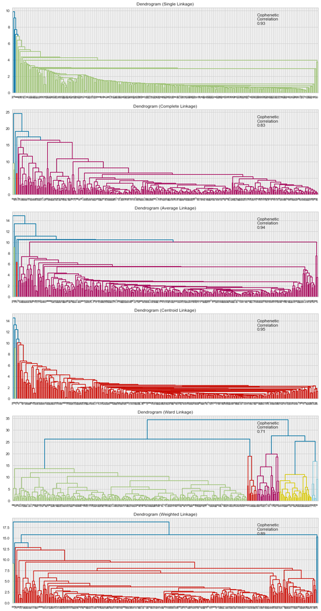

```python
# list of linkage methods
linkage_methods = ["single", "complete", "average", "centroid", "ward", "weighted"]

# lists to save results of cophenetic correlation calculation
compare_cols = ["Linkage", "Cophenetic Coefficient"]

# to create a subplot image
fig, axs = plt.subplots(len(linkage_methods), 1, figsize=(15, 30))

# We will enumerate through the list of linkage methods above
# For each linkage method, we will plot the dendrogram and calculate the cophenetic correlation
for i, method in enumerate(linkage_methods):
    Z = linkage(subset_scaled_df1, metric="euclidean", method=method)

    dendrogram(Z, ax=axs[i])
    axs[i].set_title(f"Dendrogram ({method.capitalize()} Linkage)")

    coph_corr, coph_dist = cophenet(Z, pdist(subset_scaled_df1))
    axs[i].annotate(
        f"Cophenetic\nCorrelation\n{coph_corr:0.2f}",
        (0.80, 0.80),
        xycoords="axes fraction",
    )
```

```python
HCmodel = AgglomerativeClustering(n_clusters=7, affinity="euclidean", linkage="average")
HCmodel.fit(subset_scaled_df1)
```

```
AgglomerativeClustering(linkage='average', n_clusters=7)
```

```python
subset_scaled_df1["HC_Clusters"] = HCmodel.labels_
df1["HC_Clusters"] = HCmodel.labels_
```

## Cluster Profiling: Euclidean Average Linkage

```python
cluster_profile = data.groupby("Security").mean()
```

```python
cluster_profile["count_in_each_segments"] = (
    df1.groupby("Security")["Price_Change"].count().values
)
```

```python
# let's see the names of the countries in each cluster
for cl in df1["HC_Clusters"].unique():
    print("In cluster {}, the following companies are present:".format(cl))
    print(df1[df1["HC_Clusters"] == cl]["Security"].unique())
    print()
```

```
In cluster 6, the following companies are present:
['American Airlines Group' 'AbbVie' 'Abbott Laboratories'
 'Adobe Systems Inc' 'Analog Devices, Inc.' 'Archer-Daniels-Midland Co'
 'Ameren Corp' 'American Electric Power' 'AFLAC Inc'
 'American International Group, Inc.' 'Apartment Investment & Mgmt'
 'Assurant Inc' 'Arthur J. Gallagher & Co.' 'Akamai Technologies Inc'
 'Albemarle Corp' 'Alaska Air Group Inc' 'Allstate Corp' 'Allegion'
 'Applied Materials Inc' 'AMETEK Inc' 'Affiliated Managers Group Inc'
 'Amgen Inc' 'Ameriprise Financial' 'American Tower Corp A'
 'AutoNation Inc' 'Anthem Inc.' 'Aon plc' 'Anadarko Petroleum Corp'
 'Amphenol Corp' 'Arconic Inc' 'Activision Blizzard'
 'AvalonBay Communities, Inc.' 'Broadcom'
 'American Water Works Company Inc' 'American Express Co' 'Boeing Company'
 'Baxter International Inc.' 'BB&T Corporation' 'Bard (C.R.) Inc.'
 'Baker Hughes Inc' 'BIOGEN IDEC Inc.' 'The Bank of New York Mellon Corp.'
 'Ball Corp' 'Bristol-Myers Squibb' 'Boston Scientific' 'BorgWarner'
 'Boston Properties' 'Citigroup Inc.' 'Caterpillar Inc.' 'Chubb Limited'
 'CBRE Group' 'Crown Castle International Corp.' 'Carnival Corp.'
 'Celgene Corp.' 'CF Industries Holdings Inc' 'Citizens Financial Group'
 'Church & Dwight' 'C. H. Robinson Worldwide' 'Charter Communications'
 'CIGNA Corp.' 'Cincinnati Financial' 'Colgate-Palmolive' 'Comerica Inc.'
 'CME Group Inc.' 'Chipotle Mexican Grill' 'Cummins Inc.' 'CMS Energy'
 'Centene Corporation' 'CenterPoint Energy' 'Capital One Financial'
 'Cabot Oil & Gas' 'The Cooper Companies' 'CSX Corp.' 'CenturyLink Inc'
 'Cognizant Technology Solutions' 'Citrix Systems' 'CVS Health'
 'Chevron Corp.' 'Concho Resources' 'Dominion Resources' 'Delta Air Lines'
 'Du Pont (E.I.)' 'Deere & Co.' 'Discover Financial Services'
 'Quest Diagnostics' 'Danaher Corp.' 'The Walt Disney Company'
 'Discovery Communications-A' 'Discovery Communications-C'
 'Delphi Automotive' 'Digital Realty Trust' 'Dun & Bradstreet'
 'Dover Corp.' 'Dr Pepper Snapple Group' 'Duke Energy' 'DaVita Inc.'
 'Devon Energy Corp.' 'eBay Inc.' 'Ecolab Inc.' 'Consolidated Edison'
 'Equifax Inc.' "Edison Int'l" 'Eastman Chemical' 'EOG Resources'
 'Equinix' 'Equity Residential' 'EQT Corporation' 'Eversource Energy'
 'Essex Property Trust, Inc.' 'E*Trade' 'Eaton Corporation'
 'Entergy Corp.' 'Edwards Lifesciences' 'Exelon Corp.' "Expeditors Int'l"
 'Expedia Inc.' 'Extra Space Storage' 'Ford Motor' 'Fastenal Co'
 'Fortune Brands Home & Security' 'Freeport-McMoran Cp & Gld'
 'FirstEnergy Corp' 'Fidelity National Information Services' 'Fiserv Inc'
 'FLIR Systems' 'Fluor Corp.' 'Flowserve Corporation' 'FMC Corporation'
```

[output cut: 68 more lines]

```

In cluster 2, the following companies are present:
['Alexion Pharmaceuticals' 'Amazon.com Inc' 'Netflix Inc.']

In cluster 0, the following companies are present:
['Apache Corporation' 'Chesapeake Energy']

In cluster 1, the following companies are present:
['Bank of America Corp' 'Intel Corp.']

In cluster 3, the following companies are present:
['Facebook']

In cluster 4, the following companies are present:
['Priceline.com Inc']
```

**We see that there are 3 clusters of one company, 2 clusters of two companies, 1 cluster of 3 companies, and all the other companies are grouped into another cluster. This clustering does not look good as the clusters do not have enough variability.**

**Let us try using Ward linkage as it has more distinct and separated clusters (as seen from it's dendrogram before). 5 appears to be the appropriate number of clusters from the dendrogram for Ward linkage.**

```python
HCmodel = AgglomerativeClustering(n_clusters=5, affinity="euclidean", linkage="ward")
HCmodel.fit(subset_scaled_df1)
```

```
AgglomerativeClustering(n_clusters=5)
```

```python
subset_scaled_df1["HC_Clusters"] = HCmodel.labels_
df1["HC_Clusters"] = HCmodel.labels_
```